# {flowchart}: A Tidy R Package for Data Flowchart Generation

Pau  
Satorra

Biostatistics Support and Research Unit, IGTP

**João Carmezim**

Biostatistics Support and Research Unit, IGTP

**Natàlia Pallarès**

Biostatistics Support and Research Unit, IGTP

**Kenneth A. Taylor**

Komodo Health, University of South Florida

Cristian  
Tebé

Biostatistics Support and Research Unit, IGTP

September 17, 2025

# Index

**1.** Introduction

**2.** The {flowchart} package

**3.** Hands-on examples

**4.** Conclusions

# Introduction

## Flowcharts

- In any study, a participant flowchart serves as a visual representation of the steps and decisions in the study workflow.
- Usually different decisions are made from the initial cohort of eligible or screened subjects until a final number of these subjects are considered to be included in the analyses.
- It is essential that the steps and numbers are clearly defined and that the process is transparent in order to ensure the reproducibility of the study and the quality of the reporting.
- In clinical research, the CONSORT, STROBE and ICH guidelines strongly recommend the use of flowcharts.

## Flowchart creation

- The creation of flowcharts are time-consuming and labor-intensive, as every screened or recruited subject must be included, without exception.
- Usually this process must be repeated many times until the database is closed for analysis.
- There are several R packages dedicated to building flowcharts: {Gmisc}, {DiagrammeR}, {consort}, {ggflowchart}.
- Some involve complex programming and manual parameterization and others are designed for building other kind of diagrams.

# The {flowchart} package

## {flowchart}

[figure not shown]

- It produces flowcharts that automatically adapt to the study database, ensuring reproducibility.
- It follows the tidyverse philosophy: from the study database we have to define a set of simple operations combined with the pipe operator (`|>` or `%>%`).
- These functions are highly customizable allowing manual parameters to be entered if necessary.

## Overview of the package

- Create a flowchart:
  - `as_fc()`
  - `fc_draw()`
  - `fc_split()`
  - `fc_filter()`
- Combine flowcharts:
  - `fc_merge()`
  - `fc_stack()`
- Customize flowcharts:
  - `fc_modify()`
  - `fc_theme()`
- Export flowcharts:
  - `fc_export()`

## `safo` dataset

- It’s the built-in dataset of the package.
- Randomly generated dataset from the SAFO clinical trial<sup>1</sup>.

| ID | did not meet inclusion criteria | met exclusion criteria | declined to participate | treatment received | intention to treat (ITT) | per protocol (PP) |
| --- | --- | --- | --- | --- | --- | --- |
| 1 | Yes | No | NA | NA | NA | NA |
| 2 | No | No | Yes | NA | NA | NA |
| 3 | No | No | No | cloxacillin plus fosfomycin | Yes | Yes |
| 4 | No | Yes | NA | NA | NA | NA |
| 5 | No | No | No | cloxacillin plus fosfomycin | Yes | Yes |
| 9 | No | No | No | cloxacillin alone | Yes | Yes |

[^1]: Grillo, S., Pujol, M., Miró, J.M. et al. Cloxacillin plus fosfomycin versus cloxacillin alone for methicillin-susceptible *Staphylococcus aureus* bacteremia: a randomized trial. Nat Med 29, 2518–2525 (2023)

# How to create a flowchart

## `as_fc()`

- Allows to initialize a dataset in the class `fc` created for this package.
- Creates a flowchart with an initial box showing the total number of rows of the dataset.

```r
library(flowchart)

safo_fc <- safo |>
  as_fc()
```

## `as_fc()`

- Allows to initialize a dataset in the class `fc` created for this package.
- Creates a flowchart with an initial box showing the total number of rows of the dataset.

```r
library(flowchart)

safo_fc <- safo |>
  as_fc()

str(safo_fc, max.level = 1)
```

```
List of 2
 $ data: tibble [925 × 21] (S3: tbl_df/tbl/data.frame)
 $ fc  : tibble [1 × 22] (S3: tbl_df/tbl/data.frame)
 - attr(*, "class")= chr "fc"
```

## `as_fc()`

`safo_fc$fc`

| id | x | y | n | N | perc | label | text_pattern | text | type | group | just | text_color | text_fs | text_fface | text_ffamily | text_padding | bg_fill | border_color | width | height | end |
| --- | --- | --- | --- | --- | --- | --- | --- | --- | --- | --- | --- | --- | --- | --- | --- | --- | --- | --- | --- | --- | --- |
| 1 | 0.5 | 0.5 | 925 | 925 | 100 | Initial dataframe | {label} {N} | Initial dataframe 925 | init | NA | center | black | 8 | 1 | NA | 1 | white | black | NA | NA | TRUE |

## `fc_draw()`

- Allows to draw a previously created `fc` object:

```r
safo |>
  as_fc()
```

## `fc_draw()`

- Allows to draw a previously created `fc` object:

```r
safo |>
  as_fc() |>
  fc_draw()
```

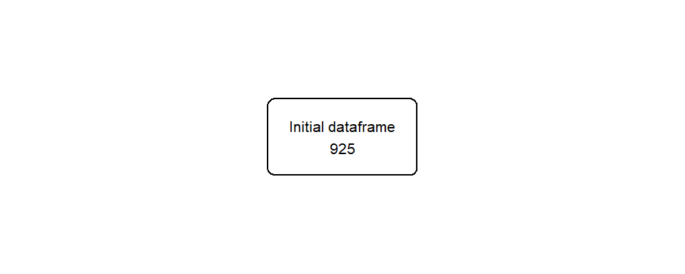

## `fc_draw()`

- Allows to draw a previously created `fc` object:

```r
safo |>
  as_fc(label = "Patients assessed for eligibility") |>
  fc_draw()
```

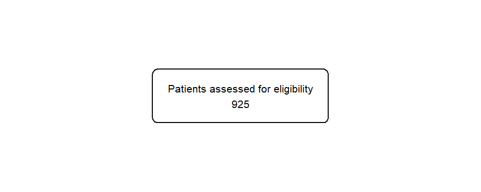

- We can use the `label` argument to modify the box label.

## `fc_filter()`

- We can filter an existing flowchart specifying the logic in which the filter is to be applied:

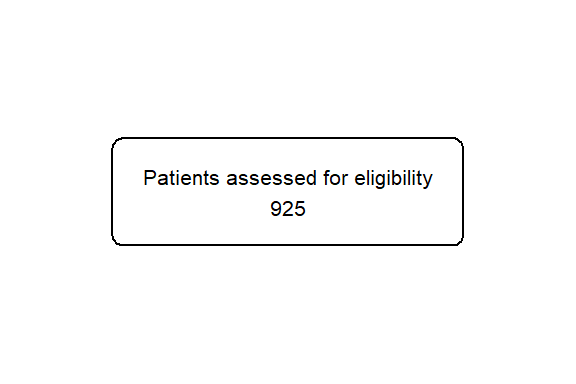

```r
safo |>
  as_fc(label = "Patients assessed for eligibility") |>
  fc_draw()
```

## `fc_filter()`

- We can filter an existing flowchart specifying the logic in which the filter is to be applied:

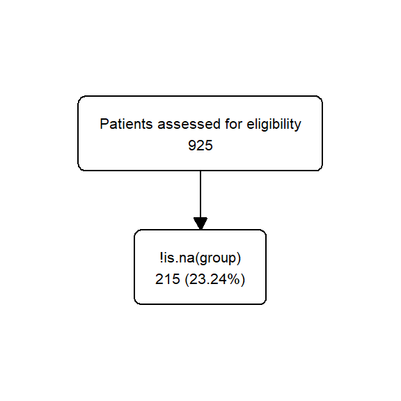

```r
safo |>
  as_fc(label = "Patients assessed for eligibility") |>
  fc_filter(!is.na(group)) |>
  fc_draw()
```

## `fc_filter()`

- We can filter an existing flowchart specifying the logic in which the filter is to be applied:

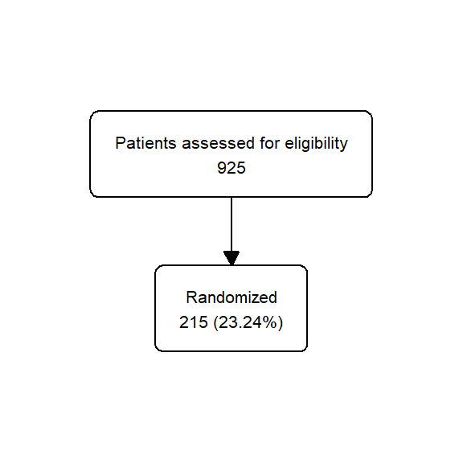

```r
safo |>
  as_fc(label = "Patients assessed for eligibility") |>
  fc_filter(!is.na(group), label = "Randomized") |>
  fc_draw()
```

- We can change again the `label`.

## `fc_filter()`

- We can filter an existing flowchart specifying the logic in which the filter is to be applied:

```r
safo |>
  as_fc(label = "Patients assessed for eligibility") |>
  fc_filter(!is.na(group), label = "Randomized", show_exc = TRUE) |>
  fc_draw()
```

[output not shown]

- We can change again the `label`.
- We can use `show_exc=TRUE` to show the excluded rows.

## `fc_split()`

- We can split an existing flowchart according to the different values of a column:

```r
safo |>
  as_fc(label = "Patients assessed for eligibility") |>
  fc_filter(!is.na(group), label = "Randomized", show_exc = TRUE) |>
  fc_draw()
```

## `fc_split()`

- We can split an existing flowchart according to the different values of a column:

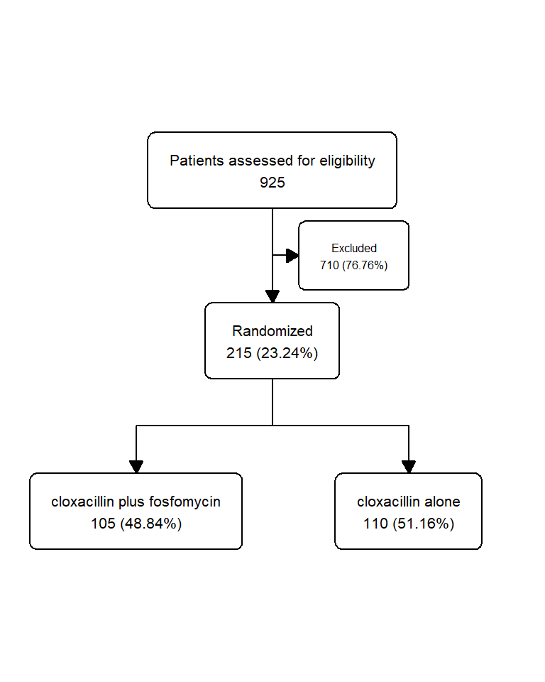

```r
safo |>
  as_fc(label = "Patients assessed for eligibility") |>
  fc_filter(!is.na(group), label = "Randomized", show_exc = TRUE) |>
  fc_split(group) |>
  fc_draw()
```

# Customize a flowchart

## Modify function arguments

- We can customize the flowchart either with the arguments provided by each function: `as_fc()`, `fc_filter()` and `fc_split()`.

| `label=` | modify the label. |
| --- | --- |
| `text_pattern=` | modify the pattern of the text (e.g. `{label}\n {n} ({perc}%)`. |
| `round_digits=` | number of digits to round percentages (default is 2) |
| `text_color=` | modify the color of the text. |
| `text_fs=` | modify the font size of the text. |
| `bg_fill=` | modify the background color of the box. |

…

- We can use the `fc_theme()` function to modify at once all arguments for all boxes.

# Export flowcharts

## `fc_export()`

- We can export the drawn flowchart to some of the most popular graphic devices.
- These include both bitmap (`png`, `jpeg`, `tiff`, `bmp`) and vector (`svg`, `pdf`) formats.

```r
safo |>
  as_fc(label = "Patients assessed for eligibility") |>
  fc_filter(!is.na(group), label = "Randomized", show_exc = TRUE) |>
  fc_draw()
```

## `fc_export()`

- We can export the drawn flowchart to some of the most popular graphic devices.
- These include both bitmap (`png`, `jpeg`, `tiff`, `bmp`) and vector (`svg`, `pdf`) formats.

```r
safo |>
  as_fc(label = "Patients assessed for eligibility") |>
  fc_filter(!is.na(group), label = "Randomized", show_exc = TRUE) |>
  fc_draw() |>
  fc_export("flowchart.png")
```

## `fc_export()`

- We can export the drawn flowchart to some of the most popular graphic devices.
- These include both bitmap (`png`, `jpeg`, `tiff`, `bmp`) and vector (`svg`, `pdf`) formats.

```r
safo |>
  as_fc(label = "Patients assessed for eligibility") |>
  fc_filter(!is.na(group), label = "Randomized", show_exc = TRUE) |>
  fc_draw() |>
  fc_export("flowchart.png", width = 3000, height = 4000, res = 700)
```

- We can customize the size and resolution of the image to save.

# Hands-on examples

## Example 1

- We will try to build a flowchart for the complete participant flow of the SAFO study trial:

## Example 1

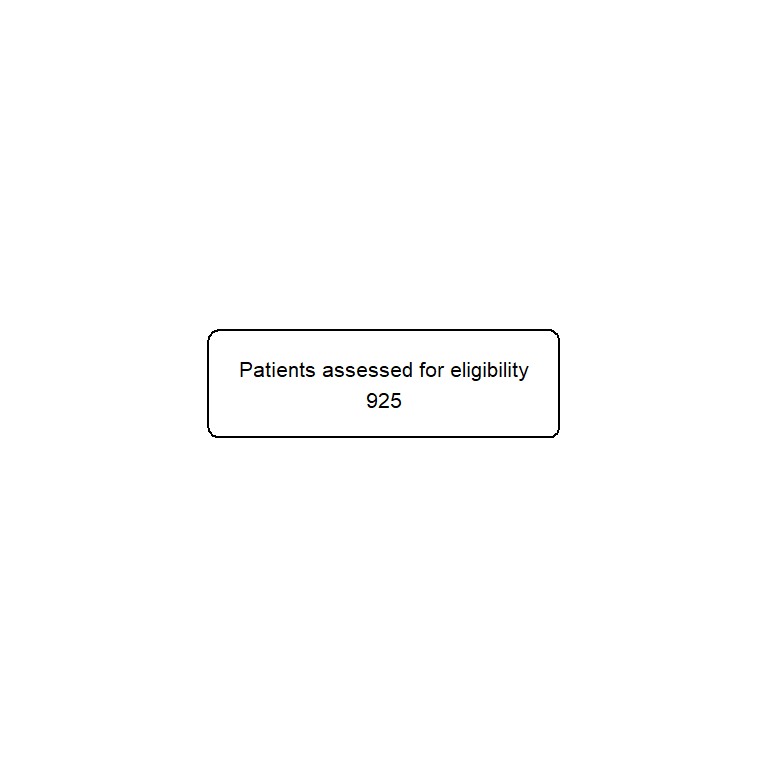

```r
safo |>
  as_fc(label = "Patients assessed for eligibility") |>
  fc_draw()
```

## Example 1

```r
safo |>
  as_fc(label = "Patients assessed for eligibility") |>
  fc_filter(!is.na(group), label = "Randomized", show_exc = TRUE) |>
  fc_draw()
```

[output not shown]

## Example 1

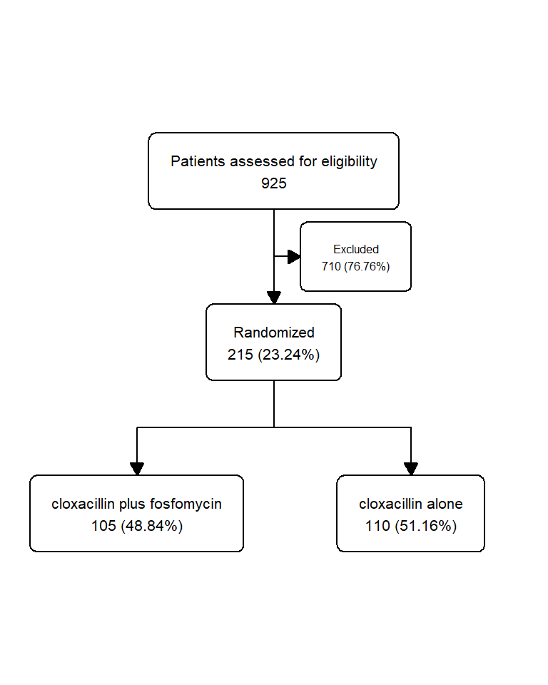

```r
safo |>
  as_fc(label = "Patients assessed for eligibility") |>
  fc_filter(!is.na(group), label = "Randomized", show_exc = TRUE) |>
  fc_split(group) |>
  fc_draw()
```

## Example 1

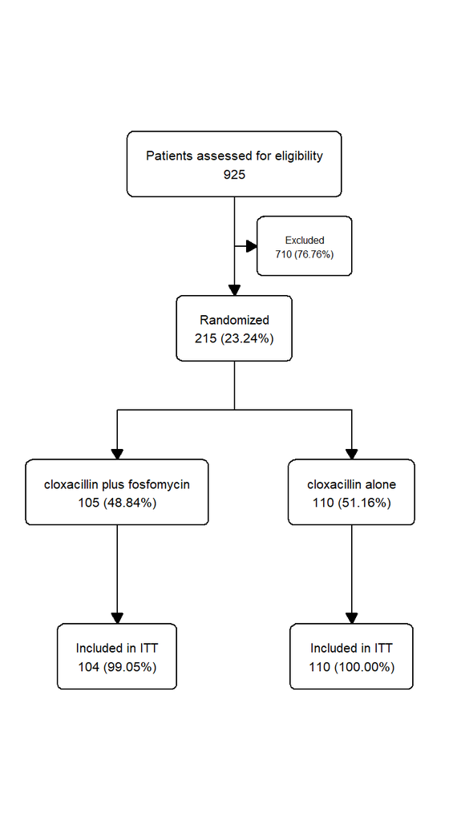

```r
safo |>
  as_fc(label = "Patients assessed for eligibility") |>
  fc_filter(!is.na(group), label = "Randomized", show_exc = TRUE) |>
  fc_split(group) |>
  fc_filter(itt == "Yes", label = "Included in ITT") |>
  fc_draw()
```

## Example 1

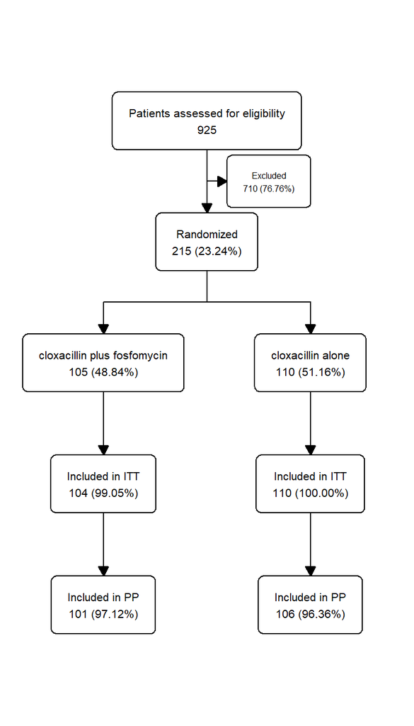

```r
safo |>
  as_fc(label = "Patients assessed for eligibility") |>
  fc_filter(!is.na(group), label = "Randomized", show_exc = TRUE) |>
  fc_split(group) |>
  fc_filter(itt == "Yes", label = "Included in ITT") |>
  fc_filter(pp == "Yes", label = "Included in PP") |>
  fc_draw()
```

## Example 1

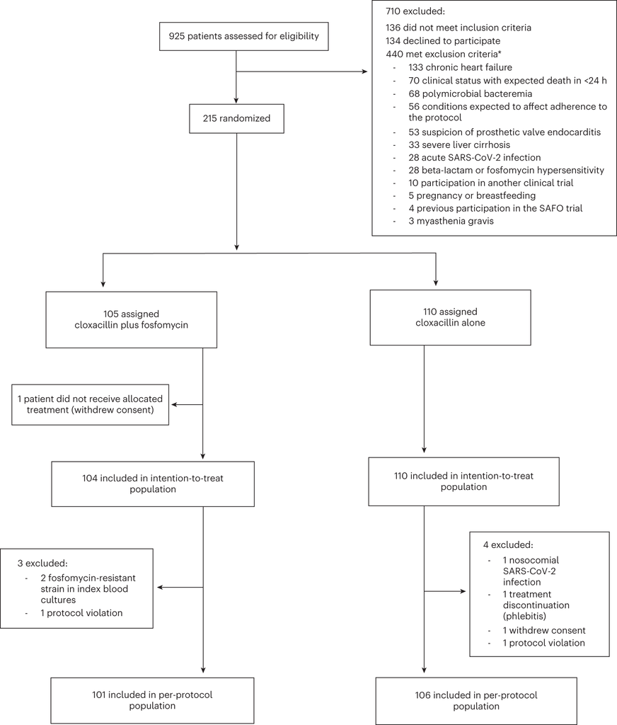

Grillo, S., Pujol, M., Miró, J.M. et al. Cloxacillin plus fosfomycin versus cloxacillin alone for methicillin-susceptible *Staphylococcus aureus* bacteremia: a randomized trial. Nat Med 29, 2518–2525 (2023). https://doi.org/10.1038/s41591-023-02569-0

## Example 2

- Now, we will create a flowchart without any dataset using the `N=` argument:

## Example 2

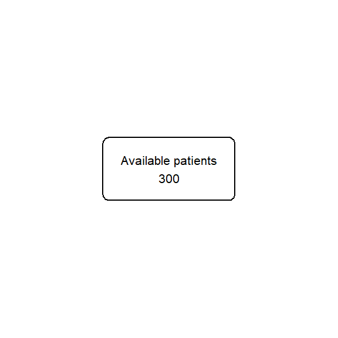

```r
as_fc(N = 300, label = "Available patients") |>
  fc_draw()
```

## Example 2

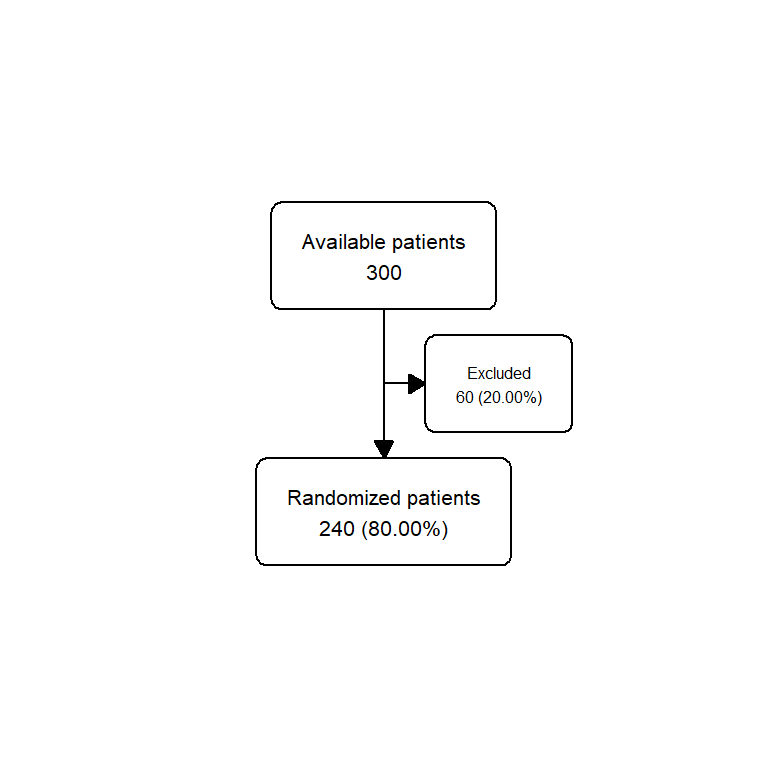

```r
as_fc(N = 300, label = "Available patients") |>
  fc_filter(N = 240, label = "Randomized patients", show_exc = TRUE) |>
  fc_draw()
```

## Example 2

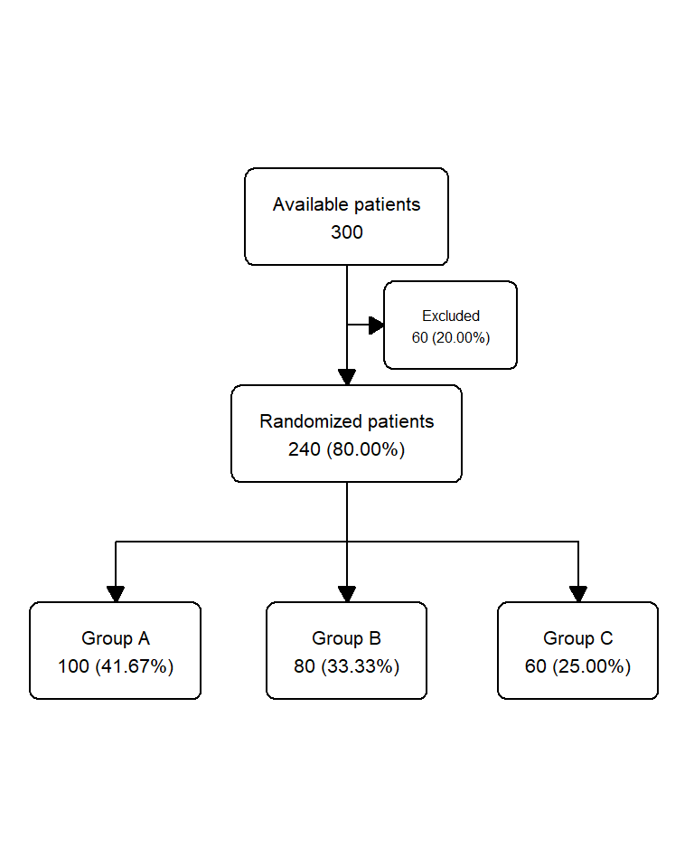

```r
as_fc(N = 300, label = "Available patients") |>
  fc_filter(N = 240, label = "Randomized patients", show_exc = TRUE) |>
  fc_split(N = c(100, 80, 60), label = c("Group A", "Group B", "Group C")) |>
  fc_draw()
```

## Example 2

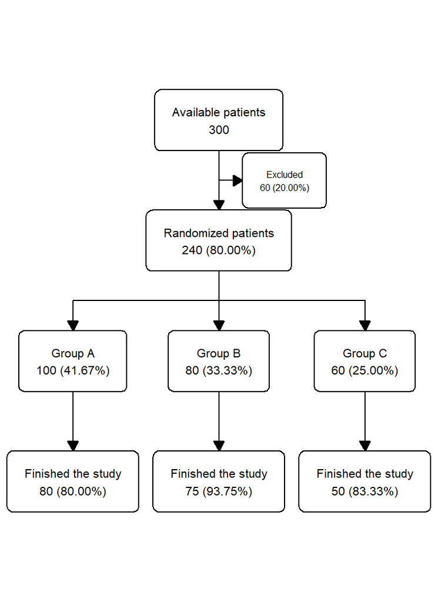

```r
as_fc(N = 300, label = "Available patients") |>
  fc_filter(N = 240, label = "Randomized patients", show_exc = TRUE) |>
  fc_split(N = c(100, 80, 60), label = c("Group A", "Group B", "Group C")) |>
  fc_filter(N = c(80, 75, 50), label = "Finished the study") |>
  fc_draw()
```

# Conclusions

## Conclusions

- A clear and detailed reporting of the flow of participants in health research studies is required and recommended.
- With this package, flowchart programming in R is made easier and accessible within the tidyverse workflow.
- Flowchart reproducibility is assured.
- As a limitation, we have not considered all possible scenarios and study designs, although is highly customizable.

## Code repository

[github.com/bruigtp](https://github.com/bruigtp/)

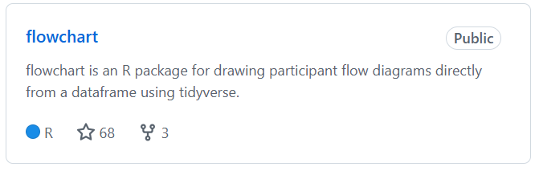

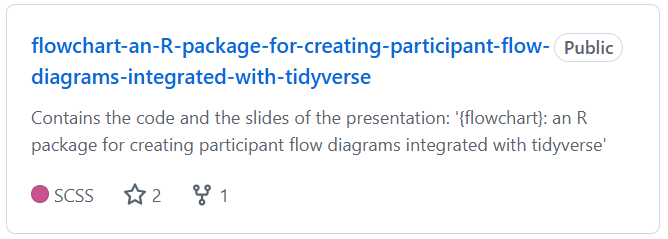

# Thank you!

[figure not shown]

[bruigtp.github.io/flowchart](https://bruigtp.github.io/flowchart/)